# Data generating processes in dgp.R

This file states the three data generating processes (DGPs) in `workflow/scripts/lib/dgp.R` as formal models. Each section names the function that implements it.

# Notation

| Symbol | Argument | Default | Meaning |
| --- | --- | --- | --- |
| $S$ | `n_sets` |  | number of independent data sets |
| $n$ | `n_obs` |  | observations in one data set |
| $n_{\max}$ | `n_obs_max` |  | rows drawn before the first $n$ are kept |
| $D$ | `n_dim` = `length(beta)` | 3 | columns of $X$, intercept included |
| $\beta$ | `beta` | `make_beta_coeff()` | coefficients |
| $\Delta$ | `out_dev` |  | outlier deviation |
| $n_{\text{out}}$ | `n_obs_out` | 1 | number of outliers |
| $\sigma^2$ | `sigma2_d` | 1 | Gaussian noise variance |

The data sets $s = 1, \dots, S$ are independent. The formulas below are for one data set, so the index $s$ is dropped.

The outlier set is the first $n_{\text{out}}$ observations:

$$\mathcal{O} = \{1, \dots, \min(n_{\text{out}}, n)\}.$$

# Shared parts

## Coefficients

`make_beta_coeff(beta_t, n_dim = 3, beta_other = 1, beta_intercept = 0)` returns

$$\beta = (\beta_0, \beta_1, \dots, \beta_{D-2}, \beta_t)
= (0, 1, \dots, 1, \beta_t).$$

Model A omits the last covariate. Model B includes it. So $\beta_t$ is the effect that only model B can capture.

## Covariates

For each observation $i = 1, \dots, n$:

$$x_i = (1, x_{i1}, \dots, x_{i,D-1}), \qquad
x_{ij} \overset{\text{iid}}{\sim} \mathcal{N}(0, 1).$$

All three families draw the covariates in the same way.

## Common random numbers

Each function draws $n_{\max}$ rows and keeps the first $n$. Thus cells with a different $n$ share the first $n$ covariate rows. The Gaussian noise and the uniforms of the binomial and Poisson models are also drawn for $n_{\max}$ rows. So cells also share the first $n$ responses, up to the change in $\eta_i$ that the outlier makes.

# Gaussian model

Function: `make_data_gaussian()`.

$$\begin{aligned}
y_i &= x_i^\top \beta + \varepsilon_i, \\
\varepsilon_i &\sim \mathcal{N}(\mu_i, \sigma^2), \\
\mu_i &=
\begin{cases}
\Delta \sqrt{\sigma^2 + \lVert \beta \rVert_2^2} & i \in
\mathcal{O}, \\
0 & \text{otherwise}.
\end{cases}
\end{aligned}$$

Equivalently, $y_i \sim \mathcal{N}(x_i^\top \beta + \mu_i, \sigma^2)$.

- The shift scales with the marginal standard deviation of $y_i$: $\operatorname{Var}(x_i^\top \beta) = \sum_{j \ge 1} \beta_j^2$.
- The code uses `sum(beta^2)`. This sum includes $\beta_0^2$. With the default $\beta_0 = 0$ the two are equal.

# Binomial (Bernoulli) model

Function: `make_data_binomial()`.

$$\begin{aligned}
\eta_i &= x_i^\top \beta, \\
\tilde\eta_i &=
\begin{cases}
\eta_i - \Delta \, s(\eta_i) & i \in \mathcal{O}, \\
\eta_i & \text{otherwise},
\end{cases} \\
y_i &\sim
\operatorname{Bernoulli}\!\left(\operatorname{logit}^{-1}(\tilde\eta_i)\right),
\end{aligned}$$

with the sign function `sign_pos()`:

$$s(x) =
\begin{cases}
-1 & x < 0, \\
+1 & x \ge 0.
\end{cases}$$

- The shift moves $\eta_i$ towards the other class. A large $\Delta$ makes the outlier almost surely the class that its covariates argue against.
- $s(0) = +1$, so the shift is never zero.
- The code draws $u_i \sim \mathcal{U}(0, 1)$ and sets $y_i = \mathbb{1}\{u_i < \operatorname{logit}^{-1}(\tilde\eta_i)\}$.
- $\Delta$ is on the logit scale.

# Poisson model

Function: `make_data_poisson()`. Constants: `POIS_SCALE` $= c = 0.5$ and `POIS_INTERCEPT` $= b_0 = 1$.

The coefficients are rescaled. The intercept is replaced:

$$b = (b_0, \, c\,\beta_1, \dots, c\,\beta_{D-1}).$$

$$\begin{aligned}
\eta_i &= x_i^\top b, \\
\tilde\eta_i &=
\begin{cases}
\eta_i + \Delta & i \in \mathcal{O}, \\
\eta_i & \text{otherwise},
\end{cases} \\
y_i &\sim \operatorname{Poisson}\!\left(\exp(\tilde\eta_i)\right).
\end{aligned}$$

- The shift is always upwards. A downward shift gives counts near 0. Such counts are common at a rate near $e$, so the outlier would be weak.
- $\Delta$ is on the log scale. The outlier rate is $e^{\Delta}$ times the rate of its covariates.
- The code draws $u_i \sim \mathcal{U}(0, 1)$ and sets $y_i = F^{-1}(u_i \mid \exp(\tilde\eta_i))$, with $F$ the Poisson distribution function (`qpois()`).
- With the defaults, the median of $\eta_i$ is 1, so the median rate is $e$. `beta_intercept` has no effect.

# Summary

|  | Gaussian | Binomial | Poisson |
| --- | --- | --- | --- |
| Linear predictor | $x_i^\top \beta$ | $x_i^\top \beta$ | $x_i^\top b$, $b = (1, 0.5\,\beta_{1:})$ |
| Link | identity | logit | log |
| Outlier shift | $+\Delta \sqrt{\sigma^2 + \lVert\beta\rVert^2}$ on $\varepsilon_i$ | $-\Delta\, s(\eta_i)$ on $\eta_i$ | $+\Delta$ on $\eta_i$ |
| Scale of $\Delta$ | SD of $y$ | logit | log |

# One draw for each family

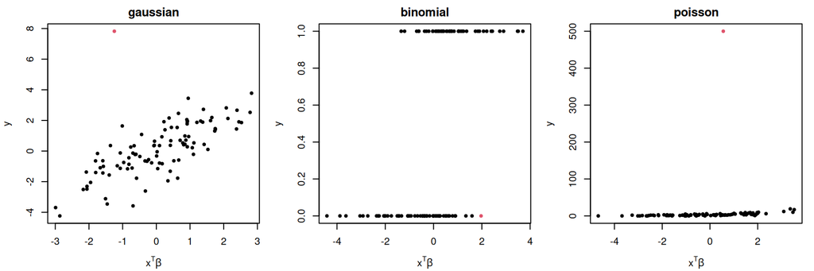

```r
set.seed(1)
beta <- make_beta_coeff(1)
n <- 100

op <- par(mfrow = c(1, 3), mar = c(4, 4, 2, 1))
for (fam in c("gaussian", "binomial", "poisson")) {
  d <- make_data_family(fam, 1, n, n, beta, out_dev = 5)
  eta <- drop(d$X[, , 1] %*% beta)
  plot(eta, d$y[, 1], col = c(2, rep(1, n - 1)), pch = 19, cex = 0.6,
       xlab = expression(x^T * beta), ylab = "y", main = fam)
}
```

```r
par(op)
```

The red point is the outlier ($i = 1$).

# Rule `data` on example cells

This section runs `workflow/scripts/generate_data.R`, the script of rule `data`, outside Snakemake. A mock `snakemake` object gives the script its input. The input comes from `config/small.yaml` and `config/cells_small.tsv`.

## Input

```r
config <- yaml::read_yaml("config/small.yaml")
cells <- read.delim(config$cells, stringsAsFactors = FALSE)
# As read_cells() and N_OBS_MAX in workflow/rules/common.smk.
n_obs_max <- max(cells$n_obs)
example <- c(gaussian = "n64_b1_o20",
             binomial = "bin_n64_b1_o5",
             poisson = "pois_n64_b1_o2")
cells[match(example, cells$cell), ]
```

```
##              cell   family n_obs beta_t out_dev n_chunks
## 8      n64_b1_o20 gaussian    64      1      20        2
## 16  bin_n64_b1_o5 binomial    64      1       5        1
## 24 pois_n64_b1_o2  poisson    64      1       2        2
```

```r
config[c("n_sets_train", "n_sets_test_gaussian", "n_sets_test_binomial",
         "n_sets_test_poisson", "seed")]
```

```
## $n_sets_train
## [1] 100
##
## $n_sets_test_gaussian
## [1] 200
##
## $n_sets_test_binomial
## [1] 50
##
## $n_sets_test_poisson
## [1] 20
##
## $seed
## [1] 2958319
```

```r
n_obs_max
```

```
## [1] 64
```

## Run the script

```r
setClass("MockSnakemake", representation(
  params = "list", output = "list", log = "list", source = "function"
))

run_rule_data <- function(cell_name) {
  row <- cells[cells$cell == cell_name, ]
  cell <- list(family = row$family, n_obs = row$n_obs,
               beta_t = row$beta_t, out_dev = row$out_dev,
               n_chunks = row$n_chunks)
  dir <- file.path(tempdir(), cell_name)
  dir.create(dir, showWarnings = FALSE)
  snakemake <- new("MockSnakemake",
    params = list(cell = cell, n_sets_train = config$n_sets_train,
                  n_sets_test_gaussian = config$n_sets_test_gaussian,
                  n_sets_test_binomial = config$n_sets_test_binomial,
                  n_sets_test_poisson = config$n_sets_test_poisson,
                  n_obs_max = n_obs_max, seed = config$seed),
    output = list(train = file.path(dir, "train.rds"),
                  test = file.path(dir, "test.rds"),
                  info = file.path(dir, "data_info.rds")),
    log = list(file.path(dir, "data.log")),
    source = function(f) source(file.path("workflow/scripts", f))
  )
  env <- new.env()
  env$snakemake <- snakemake
  open_before <- getAllConnections()
  source("workflow/scripts/generate_data.R", local = env)
  # Undo start_log(): restore the message stream and close the log file.
  sink(type = "message")
  for (con in setdiff(getAllConnections(), open_before)) {
    close(getConnection(con))
  }
  list(cell = cell,
       train = readRDS(snakemake@output$train),
       test = readRDS(snakemake@output$test),
       info = readRDS(snakemake@output$info))
}

out <- lapply(example, run_rule_data)
```

## Output

The script writes three files for each cell:

- `train.rds`: `X` as `[n_obs, n_dim, n_sets_train]`, `y` as `[n_obs, n_sets_train]`.
- `test.rds`: the pooled test sets. `X` as `[n_obs * n_sets_test_<family>, n_dim]`, `y` as a vector.
- `data_info.rds`: `y_test_var`, the variance of the test `y`.

```r
for (fam in names(out)) {
  o <- out[[fam]]
  cat(sprintf(
    "%-8s train X %s, y %s | test X %s, y %d | y_test_var %.3f\n",
    fam, paste(dim(o$train$X), collapse = " x "),
    paste(dim(o$train$y), collapse = " x "),
    paste(dim(o$test$X), collapse = " x "), length(o$test$y),
    o$info$y_test_var))
}
```

```
## gaussian train X 64 x 3 x 100, y 64 x 100 | test X 12800 x 3, y 12800 | y_test_var 21.655
## binomial train X 64 x 3 x 100, y 64 x 100 | test X 3200 x 3, y 3200 | y_test_var 0.250
## poisson  train X 64 x 3 x 100, y 64 x 100 | test X 1280 x 3, y 1280 | y_test_var 32.226
```

## Checks

The outliers in the test data are the rows $(s - 1)\,n + 1$. The table compares the outliers with the other observations. It also compares the mean of $y$ with its expected value under the formal model.

For the binomial family, the mean of $y$ does not show the outlier. So for this family $y$ is replaced by the indicator that $y_i$ is the class against the sign of $\eta_i$, $\mathbb{1}\{y_i \ne \mathbb{1}\{\eta_i \ge 0\}\}$.

```r
# Linear predictor of the formal model, before the outlier shift.
true_eta <- function(family, X, beta) {
  if (family == "poisson") {
    beta <- beta * POIS_SCALE
    beta[1] <- POIS_INTERCEPT
  }
  drop(X %*% beta)
}

# Expected y of each observation under the formal model.
expected_y <- function(family, eta, out_dev, is_out, beta) {
  switch(family,
    gaussian = eta + is_out * out_dev * sqrt(1 + sum(beta^2)),
    binomial = plogis(eta - is_out * out_dev * sign_pos(eta)),
    poisson = exp(eta + is_out * out_dev)
  )
}

checks <- do.call(rbind, lapply(names(out), function(fam) {
  o <- out[[fam]]
  beta <- make_beta_coeff(o$cell$beta_t)
  n <- o$cell$n_obs
  is_out <- (seq_along(o$test$y) - 1) %% n == 0
  eta <- true_eta(fam, o$test$X, beta)
  ey <- expected_y(fam, eta, o$cell$out_dev, is_out, beta)
  y <- o$test$y
  if (fam == "binomial") {
    y <- ifelse(eta >= 0, 1 - y, y)
    ey <- ifelse(eta >= 0, 1 - ey, ey)
  }
  data.frame(
    family = fam,
    outlier_share = mean(is_out),
    mean_y_out = mean(y[is_out]),
    expected_out = mean(ey[is_out]),
    mean_y_other = mean(y[!is_out]),
    expected_other = mean(ey[!is_out]),
    y_test_var = o$info$y_test_var,
    var_check = mean((o$test$y - mean(o$test$y))^2)
  )
}))
knitr::kable(checks, digits = 3)
```

| family | outlier_share | mean_y_out | expected_out | mean_y_other | expected_other | y_test_var | var_check |
| --- | --- | --- | --- | --- | --- | --- | --- |
| gaussian | 0.016 | 34.824 | 34.741 | -0.009 | -0.009 | 21.655 | 21.655 |
| binomial | 0.016 | 0.960 | 0.968 | 0.283 | 0.275 | 0.250 | 0.250 |
| poisson | 0.016 | 28.300 | 27.663 | 3.693 | 3.540 | 32.226 | 32.226 |

## Plots

Each column is one family. The top row shows the first training set. The bottom row shows the pooled test sets. Red points are outliers. The x-axis is the linear predictor $\eta_i$ of the formal model, before the outlier shift. The binomial $y$ is jittered.

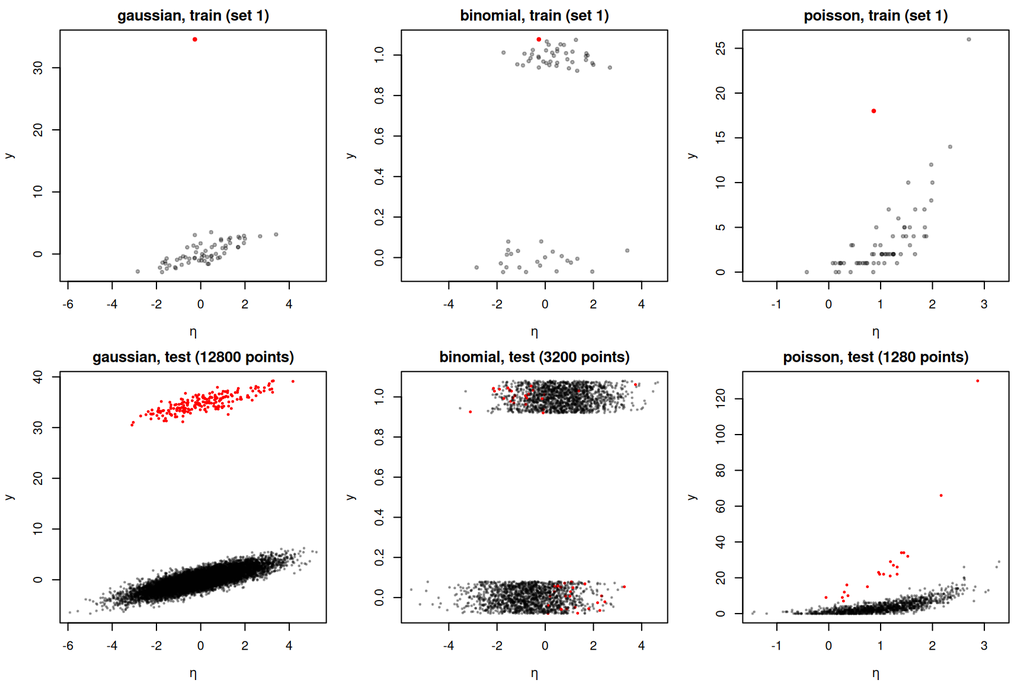

```r
# One x-range for each family, shared by its train and test plots.
xlims <- lapply(out, function(o) {
  beta <- make_beta_coeff(o$cell$beta_t)
  range(true_eta(o$cell$family, o$train$X[, , 1], beta),
        true_eta(o$cell$family, o$test$X, beta))
})

op <- par(mfrow = c(2, 3), mar = c(4, 4, 2, 1))
for (part in c("train", "test")) {
  for (fam in names(out)) {
    o <- out[[fam]]
    beta <- make_beta_coeff(o$cell$beta_t)
    if (part == "train") {
      X <- o$train$X[, , 1]
      y <- o$train$y[, 1]
    } else {
      X <- o$test$X
      y <- o$test$y
    }
    is_out <- (seq_along(y) - 1) %% o$cell$n_obs == 0
    if (fam == "binomial") y <- jitter(y, amount = 0.08)
    plot(true_eta(fam, X, beta), y, pch = 19, xlim = xlims[[fam]],
         cex = if (part == "train") 0.6 else 0.3,
         col = ifelse(is_out, "red", adjustcolor("black", 0.3)),
         xlab = expression(eta), ylab = "y",
         main = sprintf("%s, %s (%s)", fam, part,
                        if (part == "train") "set 1"
                        else paste(length(y), "points")))
  }
}
```

```r
par(op)
```